# Cambridge Sales Project

From EDA to Machine Learning

Team Shah Nawaz

2022-09-09

# 1 Project Description

## 1.1 General Overview:

- People express their character identification in unique ways and the most important manner is apparel. Someone’s self-notion is pondered via his clothing and brand preferences, and it indicates how a person would like to be.
- In the last few decades and as a result, many national and international brands have evolved in Pakistan.
- Entrepreneurs make use of brands as the principal factor of differentiation to the advantage of aggressive benefit on different competition, gambling being an imperative function in the triumph of companies [1].
- Clothes today are made from a wide range of different materials. Traditional materials such as cotton, linen and leather are still sourced from plants and animals [2].

[1] Kamran, A., Dawood, M. U., Rafi, S. K., Butt, F. M., & Akhtar, K. (2020). Impact of Brand Name on Purchase Intention: A Study on Clothing in Karachi, Pakistan. International Journal of Innovation, Creativity and Change, 278-293.

[2] Objective, C. (2021, December 10). What Are Our Clothes Made From? Retrieved from https://www.commonobjective.co/article/what-are-our-clothes-made-from

## 1.2 General Problem Statement:

[figure not shown]

[interactive chart not shown]

# 2 EDA of the project

## 2.1 Step1 - Import modules

```python
import pandas as pd
import numpy as np
import matplotlib.pyplot as plt
import seaborn as sns
import plotly.express as px
from sklearn.impute import SimpleImputer
```

## 2.2 Step2: Import data

```python
df1=pd.read_excel('/Users/snawaz/Documents/pychilla2/teamproject_sep3/Deep_note_linked/Sales.xlsx')
```

## 2.3 Step3: Make a copy of the data

```python
df=df1.copy()
```

## 2.4 Step4: Check shape oF Data

```python
rows,cols=df.shape
print("Number of rows in dataset are",rows)
```

```
## Number of rows in dataset are 670082
```

```python
print("Number of columns in the dataset are",cols)
```

```
## Number of columns in the dataset are 45
```

# 3 EDA of the project

## 3.1 Step 5: Check the data types of the columns

```python
df.info()
```

```
## <class 'pandas.core.frame.DataFrame'>
## RangeIndex: 670082 entries, 0 to 670081
## Data columns (total 45 columns):
##  #   Column             Non-Null Count   Dtype
## ---  ------             --------------   -----
##  0   BillNo             670082 non-null  object
##  1   BillDate           670082 non-null  datetime64[ns]
##  2   LoyaltyCard        33720 non-null   object
##  3   Customer           661558 non-null  object
##  4   Description        66014 non-null   object
##  5   BillMonth          670082 non-null  object
##  6   Warehouse          670082 non-null  object
##  7   RegionName         670082 non-null  object
##  8   Location           670082 non-null  object
##  9   Category           670082 non-null  object
```

[output cut: 37 more lines]

## 3.2 Step 6: Check the first 5 rows of the data

```r
DT::datatable(head(py$df))
```

|  | BillNo | BillDate | LoyaltyCard | Customer | Description | BillMonth | Warehouse | RegionName | Location | Category | DepartmentName | BrandName | CoBrand | Barcode | DesignNo | Rejection | SeasonName | Attribute1 | Attribute2 | Attribute3 | Attribute4 | Attribute5 | Attribute6 | Attribute7 | Attribute8 | LocalImport | Color | Sizes | DiscountType | … |
| --- | --- | --- | --- | --- | --- | --- | --- | --- | --- | --- | --- | --- | --- | --- | --- | --- | --- | --- | --- | --- | --- | --- | --- | --- | --- | --- | --- | --- | --- | --- |
| 1 | SALM-010116-00003 | 2016-01-01T00:00:00Z |  | . |  | 2016-01 | No | 3-NORTH | ALAM STORE | MENS SHIRT | LICENSE | LICENSE FULL SLEEVE | LICENSE F/S | 492146 | B5393 | No | WINTER 2015 - 2016 | 1 Year & Above (Discounted) | Buy 1 Get 1 free |  | CAMBRIDGE |  |  |  |  | Local | Forest Teal | LAR |  | … |
| 2 | SALM-010116-00009 | 2016-01-01T00:00:00Z |  | Mr.Shoaib sadiique | Exchnage | 2016-01 | No | 3-NORTH | ALAM STORE | MENS SHIRT | CAMBRIDGE | LUXER | LUXER PLAIN F/S | 464028 | B6335 | No | SUMMER 2015 | 1 Year & Above (Discounted) |  | PAKISTAN | CAMBRIDGE | A |  |  | Regular | Local | Pool Blue | 16 |  | … |
| 3 | SALM-010116-00009 | 2016-01-01T00:00:00Z |  | Mr.Shoaib sadiique | Exchnage | 2016-01 | No | 3-NORTH | ALAM STORE | MENS SHIRT | CAMBRIDGE | LUXER | LUXER PLAIN F/S | 464945 | B6336 | No | SUMMER 2015 | 1 Year & Above (Discounted) |  | PAKISTAN | CAMBRIDGE | B |  |  | Regular | Local | L/GREEN | 14½ |  | … |
| 4 | SALM-010116-00011 | 2016-01-01T00:00:00Z |  | Mr.Adil | Exchange | 2016-01 | No | 3-NORTH | ALAM STORE | MENS SHIRT | CAMBRIDGE | LUXER | LUXER PLAIN F/S | 464924 | B6336 | No | SUMMER 2015 | 1 Year & Above (Discounted) |  | PAKISTAN | CAMBRIDGE | B |  |  | Regular | Local | BLUE | 14½ |  | … |
| 5 | SALM-010116-00011 | 2016-01-01T00:00:00Z |  | Mr.Adil | Exchange | 2016-01 | No | 3-NORTH | ALAM STORE | MENS SHIRT | CAMBRIDGE | LUXER | LUXER PLAIN F/S | 464954 | B6336 | No | SUMMER 2015 | 1 Year & Above (Discounted) |  | PAKISTAN | CAMBRIDGE | B |  |  | Regular | Local | MEHROON | 15½ |  | … |
| 6 | SALM-010116-00014 | 2016-01-01T00:00:00Z |  | . |  | 2016-01 | No | 3-NORTH | ALAM STORE | MENS SHIRT | CAMBRIDGE | EXECUTIVE | Cambridge Executive F/S | 486942 | B9344 | No | WINTER 2015 - 2016 | 1 Year & Above (Discounted) |  | PAKISTAN | CAMBRIDGE | B |  |  | Regular | Local | MIX | 16½ |  | … |

# 4 EDA of the project

## 4.1 Step 7: Check the unique values of the data

```python
for column in df.columns :
    print('Number of unique data for {0} is {1}'.format(column , len(df[column].unique())))
    print('unique data for {0} is {1}'.format(column , df[column].unique()))
    print('=====================================')
```

```
## Number of unique data for BillNo is 439665
## unique data for BillNo is ['SALM-010116-00003' 'SALM-010116-00009' 'SALM-010116-00011' ...
##  'SDMT-241218-00112' 'SDMT-271218-00017' 'SDMT-271218-00018']
## =====================================
## Number of unique data for BillDate is 1089
## unique data for BillDate is ['2016-01-01T00:00:00.000000000' '2016-02-01T00:00:00.000000000'
##  '2016-03-01T00:00:00.000000000' ... '2018-12-23T00:00:00.000000000'
##  '2018-12-25T00:00:00.000000000' '2018-12-30T00:00:00.000000000']
## =====================================
## Number of unique data for LoyaltyCard is 5344
## unique data for LoyaltyCard is [nan 12 26 ... 32356 32370 32433]
## =====================================
## Number of unique data for Customer is 73677
## unique data for Customer is ['.' 'Mr.Shoaib sadiique' 'Mr.Adil' ... ' M HAYAT KHAN ' ' MRS IMRAN '
##  ' AIMEN IBRAHIM ']
## =====================================
## Number of unique data for Description is 11788
## unique data for Description is [nan 'Exchnage' 'Exchange' ... 'EMP-2261' ' I.D 2261' 'Blazer']
## =====================================
## Number of unique data for BillMonth is 36
## unique data for BillMonth is ['2016-01' '2016-02' '2016-03' '2016-04' '2016-05' '2016-06' '2016-07'
##  '2016-08' '2016-09' '2016-10' '2016-11' '2016-12' '2017-03' '2017-01'
##  '2017-02' '2017-05' '2017-04' '2017-06' '2017-07' '2017-08' '2017-09'
##  '2017-11' '2017-12' '2017-10' '2018-02' '2018-01' '2018-08' '2018-06'
##  '2018-07' '2018-04' '2018-03' '2018-05' '2018-11' '2018-10' '2018-09'
##  '2018-12']
## =====================================
## Number of unique data for Warehouse is 2
## unique data for Warehouse is ['No' 'Yes']
## =====================================
## Number of unique data for RegionName is 7
## unique data for RegionName is ['3-NORTH ' '1-KARACHI' '5-WAREHOUSES' '2-LAHORE' '4-CENTRAL PUNJAB '
##  '7- EXCLUDE SUB STORES' '6-SUB STORE ']
## =====================================
## Number of unique data for Location is 67
## unique data for Location is ['ALAM STORE' 'AL SAEED SUPER STORE ' 'TCS Atrium Mall'
##  'SANA ENTERPRISES ' 'TCS BEVERLY CENTER'
##  'TCS CLASSIC DEPARTMENTAL STORE (CLOSED)'
##  'CG Main Store  / A-5 2nd floor (CLOSED)' 'TCS DOLMEN CITY '
##  'TCS Dolmen Mall -Hyderi' 'TCS Dolmen Mall - Tariq Road'
```

[output cut: 965 more lines]

```
##  'LIGHT WEIGHT F/S ' 'PORTFOLIO SATEEN F/S ' 'F/S DEAD SHIRT ' 'ITALIAN'
##  'H/S AFTER HOURS           ' 'SEERSUCKER H/S SHIRT'
##  'LICENSE                  ' 'OXFORD LICENSE F/S' 'HERRING BONE F/S'
##  'MELANGE YARN DYED F/S ' 'FLANNEL F/S ' 'F/S SHARP CAMBRDIGE '
##  'CAMBRIDGE SHIRT' 'DOBBY F/S' 'Cotton Linen F/S '
##  'F/S ESSENTIALS MENS FORMAL SHIRTS' 'Cotton Slub F/S'
##  'OXFORD LICENSE H/S' 'F/S ACTIVE' 'PERSONALLY CAMBRIDGE'
##  'F/S D STUDIO              ' 'F/S ZERO TOLERANCE       ' 'F/S DOBBY'
##  'F/S HERRING BONE ' 'F/S MELANGE YARN DYED ' 'F/S LICENSE           '
##  'H/S LICENSE         ' 'H/S OXFORD LICENSE ' 'F/S OVERDYE '
##  'F/S OXFORD LICENSE ' 'F/S COTTON LINEN ' 'F/S PRINTED SHIRTS'
##  'H/S SEERSUCKER SHIRT' 'F/S CHEMBREY' 'H/S CHEMBREY ' 'F/S COTTON SLUB '
##  'F/S SEERSUCKER SHIRT' 'F/S FLANNEL' 'F/S AGE OF WISDOM '
##  'CAMBRIDGE UNIFORM ' 'F/S LIGHT WEIGHT ']
## =====================================
```

## 4.2 Step 8: Check the null values of the data

```python
percent_missing = df.isnull().sum() * 100 / len(df)
missing_value_df = pd.DataFrame({'percent_missing': percent_missing})

missing_value_df
```

```
##                    percent_missing
## BillNo                    0.000000
## BillDate                  0.000000
## LoyaltyCard              94.967780
## Customer                  1.272083
## Description              90.148370
## BillMonth                 0.000000
## Warehouse                 0.000000
## RegionName                0.000000
## Location                  0.000000
## Category                  0.000000
## DepartmentName            0.000000
## BrandName                 0.231613
## CoBrand                   0.000000
## Barcode                   0.000000
## DesignNo                  0.000000
## Rejection                 0.000000
## SeasonName                0.000000
## Attribute1                0.003731
## Attribute2               78.640674
## Attribute3               53.847141
## Attribute4                0.000000
## Attribute5               49.659594
## Attribute6              100.000000
## Attribute7              100.000000
## Attribute8               26.839700
## LocalImport               0.000000
## Color                     0.000000
## Sizes                     0.000000
## DiscountType             24.951573
## SalesmanName              0.000000
## Qty                       0.000000
## SalesReturnReason        97.793404
## Price                     0.000000
## Amount                    0.000000
## SaleExclGST               0.000000
## GSTP                      0.000000
## GST                       0.000000
## DiscPer                   0.000000
## DiscAmount                0.000000
## BarcodeDiscPer            0.000000
## BarcodeDiscount           0.000000
## NetAmount                 0.000000
## PointsEarned              0.000000
## TaxPer                    0.000000
## Cobrand Acc               0.000000
```

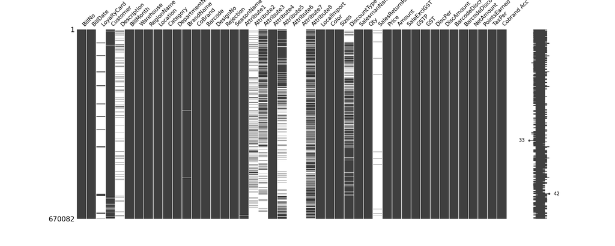

```python
msno.matrix(df)
```

```python
df.drop(['Attribute6','Attribute7'],axis=1,inplace=True)
```

# 5 EDA of the project

## 5.1 Step 9: Dropping useless columns

```python
df.Attribute4.unique()
```

```
## array(['CAMBRIDGE'], dtype=object)
```

Column `Salemanname` is a useless feature since we are not interested to identify the sales by each person to avoid bias in decision making.

```python
df.drop('Attribute4',axis=1,inplace=True)
df.drop('SalesmanName',axis=1,inplace=True)
df.drop('Category',axis=1,inplace=True)
```

The data between columns `CoBrand` and `CoBrand Acc` is 99% similar so we are keeping only column out of it.

```python
from fuzzywuzzy import fuzz

fuzz.token_sort_ratio(df['CoBrand'], df['Cobrand Acc'])
```

[output not shown]

```python
df.drop('CoBrand',axis=1,inplace=True)
df.drop('Barcode',axis=1,inplace=True)
```

# 6 EDA of the project

## 6.1 Data Preprocessing

### 6.1.1 Renaming some columns

Based on the data description, we are renaming some columns to make it more readable

- Attribute1 is the Inventory_status which shows the cloth which come back to ware house and go back for sales
- Attribute2 is the offer ctypes at the shops.
- Attribute8 is the type of the cloth.
- Attribute3 is the import from which cloth is imported.

```python
df = df.rename(columns={'Attribute1':'Inventory_status',
'Attribute2':'Offers','Attribute8':'Class_of_cloth',
'Attribute3':'Import_type'})
```

### 6.1.2 For customer column

- Using returning and non-returning customers.
- We identify the customers by names and assume that customers with identical names is actually a returning customer.
- We will look in graphs if the returning customers are more profitable than the non-returning customers.

```python
df['Customer']=df.Customer.duplicated()
df['Customer'].replace(True,'Returning_Costumer',inplace=True) #<<
df['Customer'].replace(False,'NoN_Returning_Costumer',inplace=True) #<<
df.Customer.value_counts()
```

```
## Returning_Costumer        596405
## NoN_Returning_Costumer     73677
## Name: Customer, dtype: int64
```

```python
df['LoyaltyCard']=df.LoyaltyCard.duplicated()
df['LoyaltyCard'].replace(True,'Yes',inplace=True)
df['LoyaltyCard'].replace(False,'No',inplace=True)
```

# 7 EDA of the project

### 7.0.1 Column Imputing by sklearn Imputing

We used the sklearn imputer to impute the missing values in the data. We used the most frequent value to impute the missing values in the data.

```python
imp = SimpleImputer(strategy="most_frequent")
df['Inventory_status']=imp.fit_transform(df[['Inventory_status']])

imp = SimpleImputer(strategy="most_frequent") #<<
df['Import_type']=imp.fit_transform(df[['Import_type']])

df['Offers']=imp.fit_transform(df[['Offers']])
df['Attribute5']=imp.fit_transform(df[['Attribute5']])
df['BrandName']=imp.fit_transform(df[['BrandName']])
df['Description']=imp.fit_transform(df[['Description']])
df['Inventory_status']=imp.fit_transform(df[['Inventory_status']])

df.SalesReturnReason = df.SalesReturnReason.replace(np.nan,'No information available')
df.Class_of_cloth = df.Class_of_cloth.replace(np.nan, "No information") # replacing Nan values with 0 value

df.DiscountType = df.DiscountType.replace(np.nan, 'No Discount') # replacing Nan values with Most  frequent value
```

# 8 EDA of the project

## 8.1 Summary of the data

```python
df.describe().T
```

```
##                     count         mean          std  ...     50%     75%       max
## Qty              670082.0     0.899518     0.611418  ...     1.0     1.0      45.0
## Price            670082.0  2437.725566   714.776793  ...  2259.0  2376.0    6127.0
## Amount           670082.0  2173.785338  1621.785795  ...  2259.0  2376.0  106920.0
## SaleExclGST      670082.0  1740.625980  1489.339984  ...  1663.0  2186.0   77455.0
## GSTP             670082.0     6.092880     2.285465  ...     6.0     6.0      17.0
## GST              670082.0   109.105263   120.435080  ...    95.0   125.0    4647.0
## DiscPer          670082.0     0.382138     3.200854  ...     0.0     0.0     100.0
## DiscAmount       670082.0     8.756731    95.321598  ...     0.0     0.0   14830.0
## BarcodeDiscPer   670082.0    17.706990    20.796915  ...    20.0    30.0      60.0
## BarcodeDiscount  670082.0   423.838609   536.809144  ...   484.0   713.0   32085.0
## NetAmount        670082.0  1849.731244  1581.756942  ...  1747.0  2295.0   82102.0
## PointsEarned     670082.0     1.078650     6.030229  ...     0.0     0.0     821.0
## TaxPer           670082.0     6.359038     0.973759  ...     6.0     6.0       9.0
##
## [13 rows x 8 columns]
```

# 9 Data Transformation

Now we will treat the data with outliers and apply some statistical tests

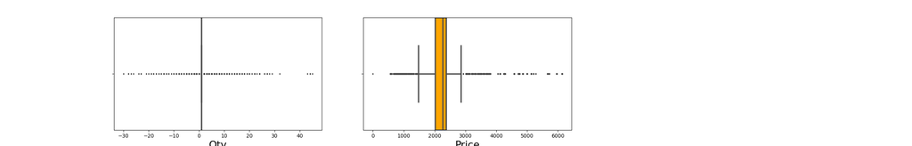

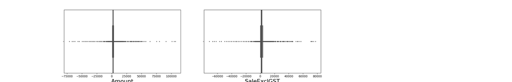

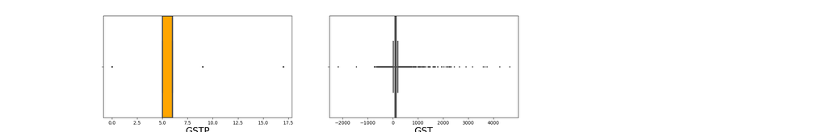

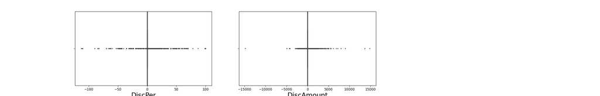

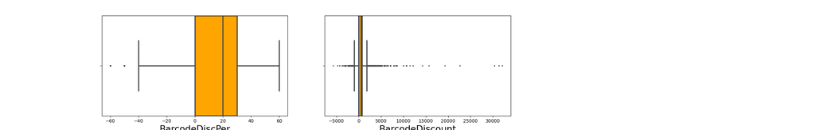

# 10 Data Transformation

```python
# Imputing outliers with mean
def impute_outliers_IQR_with_mean(df):
   Q1=df.quantile(0.25)
   Q3=df.quantile(0.75)
   IQR=Q3-Q1
    # Lower bound
   lower = Q1 - 1.5*IQR
    # Upper bound
   upper = Q3 + 1.5*IQR
   df = np.where(df > upper,
       df.mean(),
       np.where(
           df < lower,
           df.mean(), #<<
           df
           )
       )
   return df
```

### 10.0.1 Checking skewness of the data

```python
# Library for skewness
from scipy.stats import skew
print('Skew of Price',skew(df.Price))
```

```
## Skew of Price 1.7332960811793
```

```python
print('Skew of Amount',skew(df.Amount))
```

```
## Skew of Amount 0.5264229479147174
```

```python
print('Skew of SaleExclGST',skew(df.SaleExclGST))
```

```
## Skew of SaleExclGST 0.053907402377267245
```

```python
print('Skew of GSTP',skew(df.GSTP))
```

```
## Skew of GSTP 3.422663381156023
```

```python
print('Skew of GST',skew(df.GST))
```

```
## Skew of GST 1.8886742450354679
```

```python
print('Skew of BarcodeDiscPer',skew(df.BarcodeDiscPer))
```

```
## Skew of BarcodeDiscPer -0.11344278021015818
```

```python
print('Skew of BarcodeDiscount',skew(df.BarcodeDiscount))
```

```
## Skew of BarcodeDiscount 1.639017468026673
```

```python
print('Skew of NetAmount',skew(df.NetAmount))
```

```
## Skew of NetAmount 0.11210500286062883
```

```python
print('Skew of PointsEarned',skew(df.PointsEarned))
```

```
## Skew of PointsEarned 21.43903163597488
```

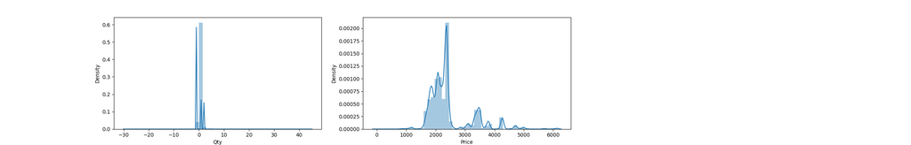

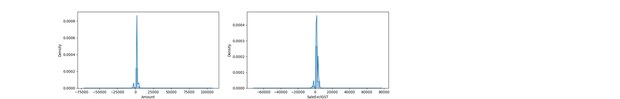

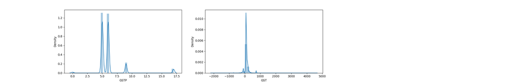

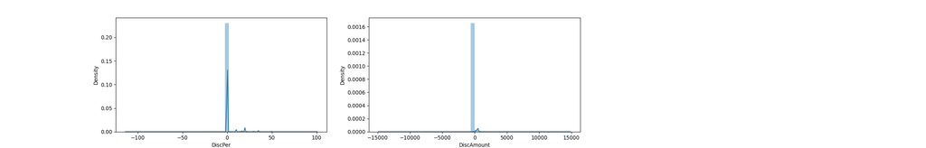

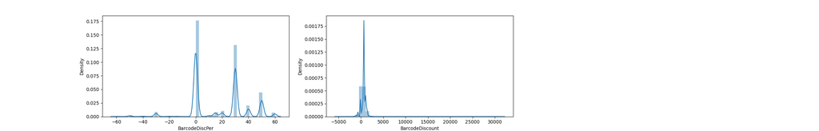

```python
cols=df.select_dtypes(include='number')
cat_cols = cols
i=0
while i < 10:
    fig = plt.figure(figsize=[25,4])

    plt.subplot(1,3,1)
    sns.distplot(a=cat_cols.iloc[:,i], hist=True)
    i += 1

    plt.subplot(1,3,2)
    sns.distplot(a=cat_cols.iloc[:,i], hist=True)
    i += 1

    plt.show()
```

# 11 Data Transformation

```python
df['Qty'] = impute_outliers_IQR_with_median(df['Qty'])
df['Price'] = impute_outliers_IQR_with_mean(df['Price'])
df['Amount'] = impute_outliers_IQR_with_median(df['Amount']) #<<
df['SaleExclGST'] = impute_outliers_IQR_with_median(df['SaleExclGST'])
df['GSTP'] = impute_outliers_IQR_with_median(df['GSTP'])
df['GST'] = impute_outliers_IQR_with_median(df['GST'])
df['BarcodeDiscPer'] = impute_outliers_IQR_with_mean(df['BarcodeDiscPer'])
df['BarcodeDiscount'] = impute_outliers_IQR_with_median(df['BarcodeDiscount'])
df['NetAmount'] = impute_outliers_IQR_with_mean(df['NetAmount'])
df['PointsEarned'] = impute_outliers_IQR_with_median(df['PointsEarned'])
df['DiscPer'] = impute_outliers_IQR_with_median(df['DiscPer'])
df['DiscAmount'] = impute_outliers_IQR_with_median(df['DiscAmount'])
```

# 12 Data Transformation

```python
# Shapiro wilk test
from scipy.stats import shapiro #<<
print('ShapiroTest of Price',shapiro(df.Price))
```

```
## ShapiroTest of Price ShapiroResult(statistic=0.8969478011131287, pvalue=0.0)
##
```

```python
print('ShapiroTest of Amount',shapiro(df.Amount))
```

```
## ShapiroTest of Amount ShapiroResult(statistic=0.908415675163269, pvalue=0.0)
```

```python
print('ShapiroTest of SaleExclGST',shapiro(df.SaleExclGST))
```

```
## ShapiroTest of SaleExclGST ShapiroResult(statistic=0.8960244059562683, pvalue=0.0)
```

```python
print('ShapiroTest of GSTP',shapiro(df.GSTP))
```

```
## ShapiroTest of GSTP ShapiroResult(statistic=0.6320035457611084, pvalue=0.0)
```

```python
print('ShapiroTest of GST',shapiro(df.GST))
```

```
## ShapiroTest of GST ShapiroResult(statistic=0.8931977152824402, pvalue=0.0)
```

```python
print('ShapiroTest of BarcodeDiscPer',shapiro(df.BarcodeDiscPer))
```

```
## ShapiroTest of BarcodeDiscPer ShapiroResult(statistic=0.8688030242919922, pvalue=0.0)
```

```python
print('ShapiroTest of BarcodeDiscount',shapiro(df.BarcodeDiscount))
```

```
## ShapiroTest of BarcodeDiscount ShapiroResult(statistic=0.8954393863677979, pvalue=0.0)
```

```python
print('ShapiroTest of NetAmount',shapiro(df.NetAmount))
```

```
## ShapiroTest of NetAmount ShapiroResult(statistic=0.9133129715919495, pvalue=0.0)
```

```python
print('ShapiroTest of PointsEarned',shapiro(df.PointsEarned))
```

```
## ShapiroTest of PointsEarned ShapiroResult(statistic=1.0, pvalue=1.0)
##
```

# 13 Data Transformation

## 13.1 Step_3 Normalization of the numeric columns.

### 13.1.1 Methods of Normalization

Four common normalization techniques may be useful:

- scaling to a range(min-max)
- clipping
- log scaling
- z-score

We use the standard scaler to normalize the data.

```python
from sklearn.preprocessing import StandardScaler
scaler = StandardScaler() #<<
df[['Qty','Price','Amount','SaleExclGST','GSTP','GST','BarcodeDiscPer','BarcodeDiscount','NetAmount','PointsEarned','DiscPer','DiscAmount']] = scaler.fit_transform(df[['Qty','Price','Amount','SaleExclGST','GSTP','GST','BarcodeDiscPer','BarcodeDiscount','NetAmount','PointsEarned','DiscPer','DiscAmount']])
```

Checking the normality after normalization

```python
from scipy.stats import shapiro
print('ShapiroTest of Price',shapiro(df.Price))
```

```
## ShapiroTest of Price ShapiroResult(statistic=0.8945704102516174, pvalue=0.0)
##
```

```python
print('ShapiroTest of Amount',shapiro(df.Amount))
```

```
## ShapiroTest of Amount ShapiroResult(statistic=0.9033786058425903, pvalue=0.0)
```

```python
print('ShapiroTest of SaleExclGST',shapiro(df.SaleExclGST))
```

```
## ShapiroTest of SaleExclGST ShapiroResult(statistic=0.8960385918617249, pvalue=0.0)
```

```python
print('ShapiroTest of GSTP',shapiro(df.GSTP))
```

```
## ShapiroTest of GSTP ShapiroResult(statistic=0.6283426880836487, pvalue=0.0)
```

```python
print('ShapiroTest of GST',shapiro(df.GST))
```

```
## ShapiroTest of GST ShapiroResult(statistic=0.8964444398880005, pvalue=0.0)
```

```python
print('ShapiroTest of BarcodeDiscPer',shapiro(df.BarcodeDiscPer))
```

```
## ShapiroTest of BarcodeDiscPer ShapiroResult(statistic=0.8605928421020508, pvalue=0.0)
```

```python
print('ShapiroTest of BarcodeDiscount',shapiro(df.BarcodeDiscount))
```

```
## ShapiroTest of BarcodeDiscount ShapiroResult(statistic=0.8955459594726562, pvalue=0.0)
```

```python
print('ShapiroTest of NetAmount',shapiro(df.NetAmount))
```

```
## ShapiroTest of NetAmount ShapiroResult(statistic=0.9149541854858398, pvalue=0.0)
```

```python
print('ShapiroTest of PointsEarned',shapiro(df.PointsEarned))
```

```
## ShapiroTest of PointsEarned ShapiroResult(statistic=1.0, pvalue=1.0)
##
```

```python
print('ShapiroTest of DiscPer',shapiro(df.DiscPer))
```

```
## ShapiroTest of DiscPer ShapiroResult(statistic=1.0, pvalue=1.0)
```

```python
print('ShapiroTest of DiscAmount',shapiro(df.DiscAmount))
```

```
## ShapiroTest of DiscAmount ShapiroResult(statistic=1.0, pvalue=1.0)
```

# 14 Applying Statistical tests

[output not shown]

```python
summary, results = rp.ttest(group1= df_karachi['Price'], group1_name= "Karachi",
                            group2= df_lahore['Price'], group2_name= "Lahore")
print(summary)
```

# 15 Machine learning Model Building

Dependent variables in various ML algorithms will be * Price for linear regression where other select features will be independent variable. * Price for multilenar regression where all other variables will be independent. * Inventory_status and `LocalImport` where all other are independent variables in classification ML model. * Price in Deep learning model * 2 Clustering Models for SeasonName.

## 15.1 Step_1: Encoding the categorical columns

```python
One_hot_encoded_data = df_Ml[['Offers']]

enc = OneHotEncoder()
enc_results = enc.fit_transform(One_hot_encoded_data)


enc=pd.DataFrame(enc_results.toarray(), columns=enc.categories_)
```

# 16 Classification Models

- Target feature: `Inventory_status` & `LocalImport`
- Independent features: All other features obrained after CV and feature selection

List of Libraries used in this all Machine learning section

```python
import pandas as pd
import numpy as np
import matplotlib.pyplot as plt
import seaborn as sns
import missingno as msno
import plotly.express as px
import scipy.special
from bokeh.layouts import gridplot
from bokeh.plotting import figure, show
import scipy.stats as stats
import xgboost as xgb
import descartes
import plotly.express as px
import folium
import sklearn

## ML libraries
from xgboost import XGBRegressor
from sklearn.linear_model import LogisticRegression,LinearRegression,RidgeCV,Lasso,LassoCV
from sklearn.impute import SimpleImputer
from sklearn.preprocessing import LabelEncoder,OneHotEncoder
from sklearn.neighbors import KNeighborsClassifier
from sklearn.ensemble import ExtraTreesClassifier,RandomForestRegressor,RandomForestClassifier,GradientBoostingClassifier
from sklearn.model_selection import train_test_split,learning_curve, cross_val_predict,cross_validate,cross_val_score,KFold
from xgboost import XGBClassifier
from sklearn.tree import DecisionTreeClassifier,DecisionTreeRegressor
from sklearn.svm import SVR,LinearSVR,SVC
from sklearn.feature_selection import RFECV , RFE
from time import time
from lightgbm import LGBMRegressor
from sklearn.metrics import pairwise_distances
from sklearn.cluster import KMeans
from sklearn.model_selection import cross_val_score,RepeatedStratifiedKFold,KFold
from sklearn.model_selection import train_test_split
from sklearn.linear_model import LinearRegression,OrthogonalMatchingPursuit
from sklearn.ensemble import StackingRegressor,ExtraTreesRegressor,RandomForestRegressor,GradientBoostingRegressor,AdaBoostRegressor
from sklearn.preprocessing import StandardScaler
from sklearn.neighbors import KNeighborsRegressor
from sklearn.model_selection import train_test_split, GridSearchCV,RepeatedKFold,RepeatedStratifiedKFold
from sklearn.metrics import f1_score, classification_report, accuracy_score, mean_squared_error, precision_score
from sklearn.metrics.cluster import adjusted_rand_score,contingency_matrix

# libraries of DL
from time import time
from sklearn.multioutput import MultiOutputRegressor
from sklearn.datasets import make_regression
from keras.models import Sequential
from keras.layers import Dense
from numpy import asarray
from pandas import set_option
from sklearn.pipeline import Pipeline

#scores
from sklearn.metrics import precision_recall_curve,confusion_matrix,mean_squared_error,mean_absolute_error,explained_variance_score,max_error,r2_score,median_absolute_error,mean_squared_log_error,silhouette_score
```

# 17 Classification Models

### 17.0.1 Step 1: Subset of large dataset

- We selected a sample of 10000 rows for comparison of different classification model.

```python
df_M = df_Ml.sample(10000).reset_index(drop=True)
```

### 17.0.2 Step2 Test train split the data

- Data is splitted before hand with 30% test data and 70% train data.

```python
X=df_M.drop('LocalImport',axis=1)
y=df_M['LocalImport']

X_train, X_test, y_train, y_test = train_test_split(X, y, test_size=0.30, random_state=44, shuffle =True)
```

### 17.0.3 Step 3: Make a list of classification models we want to apply

```python
final_clf = None
clf_names = ["Logistic Regression", "KNN(3)", "XGBoost Classifier", "Random forest classifier", "Decision Tree Classifier",
            "Gradient Boosting Classifier", "Support Vector Machine"]
```

### 17.0.4 Step4: Apply each model on 10000 rows dataset and get the scores

```python
classifiers = []
scores = []
for i in range(10):

    tempscores = []

    # logistic Regression
    lr_clf = LogisticRegression(n_jobs=-1)
    lr_clf.fit(X_train, y_train)
    tempscores.append((lr_clf.score(X_test, y_test))*100)

    # KNN n_neighbors = 3
    knn3_clf = KNeighborsClassifier(n_jobs=-1)
    knn3_clf.fit(X_train, y_train)
    tempscores.append((knn3_clf.score(X_test, y_test))*100)

    # XGBoost
    xgbc = XGBClassifier(n_jobs=-1,seed=41)
    xgbc.fit(X_train, y_train)
    tempscores.append((xgbc.score(X_test, y_test))*100)

    # Random Forest
    rf_clf = RandomForestClassifier(n_jobs=-1)
    rf_clf.fit(X_train, y_train)
    tempscores.append((rf_clf.score(X_test, y_test))*100)

    # Decision Tree
    dt_clf = DecisionTreeClassifier()
    dt_clf.fit(X_train, y_train)
    tempscores.append((dt_clf.score(X_test, y_test))*100)

    # Gradient Boosting
    gb_clf = GradientBoostingClassifier()
    gb_clf.fit(X_train, y_train)
    tempscores.append((gb_clf.score(X_test, y_test))*100)

    #SVM
    svm_clf = SVC(gamma = "scale")
    svm_clf.fit(X_train, y_train)
    tempscores.append((svm_clf.score(X_test, y_test))*100)

    scores.append(tempscores)

scores = np.array(scores)
clfs = pd.DataFrame({"Classifier":clf_names})
for i in range(len(scores)):
    clfs['iteration' + str(i)] = scores[i].T

means = clfs.mean(axis = 1)
means = means.values.tolist()

clfs["Average"] = means


clfs.set_index("Classifier", inplace = True)
print("Accuracies : ")
clfs["Average"].head(10)
```

[output not shown]